## Choosing models

The following code uses DAGs to choose and explain selection of adjustment variables for models

### DAG1: maternal and paternal preconception smoking on birthweight

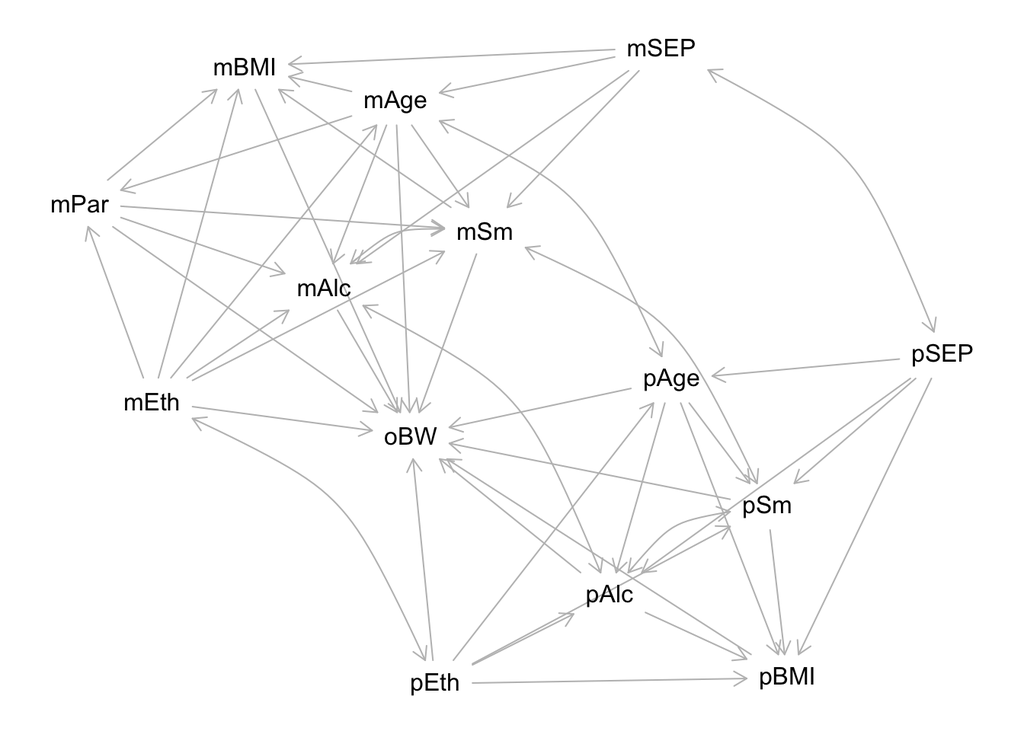

```r
library(dagitty)


g1 <- dagitty( "dag {
mEth -> mAlc
mEth -> mBMI
mEth -> mPar
mEth -> mSm
mEth -> oBW
mEth -> mAge
mEth <-> pEth
mAge -> mAlc
mAge -> mBMI
mAge -> mPar
mAge -> mSm
mAge -> oBW
mAge <-> pAge
mAlc -> oBW
mAlc <-> mSm
mAlc <-> pAlc
mBMI -> oBW
mPar -> mAlc
mPar -> mBMI
mPar -> mSm
mPar -> oBW
mSEP -> mAge
mSEP -> mAlc
mSEP -> mBMI
mSEP -> mSm
mSEP <-> pSEP
mSm -> mBMI
mSm -> oBW
mSm <-> pSm
pAge -> oBW
pAge -> pAlc
pAge -> pBMI
pAge -> pSm
pEth -> oBW
pEth -> pAlc
pEth -> pBMI
pEth -> pSm
pEth -> pAge
pAlc -> oBW
pAlc -> pBMI
pAlc <-> pSm
pBMI -> oBW
pSEP -> pAge
pSEP -> pAlc
pSEP -> pBMI
pSEP -> pSm
pSm -> oBW
pSm -> pBMI
}
")

plot(graphLayout(g1))
```

```r
adjustmentSets(g1,"pSm","oBW") #maternal age, alc, eth, parity, sep, smoking; paternal age, alcohol, eth, SEP
```

```
## { mAge, mAlc, mBMI, mEth, mPar, mSm, pAge, pAlc, pEth, pSEP }
## { mAge, mAlc, mEth, mPar, mSEP, mSm, pAge, pAlc, pEth, pSEP }
```

```r
adjustmentSets(g1,"mSm","oBW") #maternal age, eth, alc, parity, sep; paternal age, alcohol, SEP, eth, smoking
```

```
## { mAge, mAlc, mEth, mPar, mSEP, pAge, pAlc, pBMI, pEth, pSm }
## { mAge, mAlc, mEth, mPar, mSEP, pAge, pAlc, pEth, pSEP, pSm }
```

```r
adjustmentSets(g1,"pAlc","oBW") #maternal age, alc, parity, sep, smoking; paternal age, smoking, SEP
```

```
## { mAge, mAlc, mBMI, mEth, mPar, mSm, pAge, pEth, pSEP, pSm }
## { mAge, mAlc, mEth, mPar, mSEP, mSm, pAge, pEth, pSEP, pSm }
```

```r
adjustmentSets(g1,"mAlc","oBW") #maternal age, smoking, parity, sep; paternal age, smoking, SEP, alcohol
```

```
## { mAge, mBMI, mEth, mPar, mSm, pAge, pAlc, pBMI, pEth, pSm }
## { mAge, mEth, mPar, mSEP, mSm, pAge, pAlc, pBMI, pEth, pSm }
## { mAge, mBMI, mEth, mPar, mSm, pAge, pAlc, pEth, pSEP, pSm }
## { mAge, mEth, mPar, mSEP, mSm, pAge, pAlc, pEth, pSEP, pSm }
```

SUMMARY OF DAG1: adjust for both parents’ age and SEP and maternal parity also adjust for other health behaviours correlated with the main exposure

so if exposure is maternal smoking, adjust for maternal alcohol PLUS paternal alcohol and smoking

### DAG2: considering timing of exposure (maternal exposures)

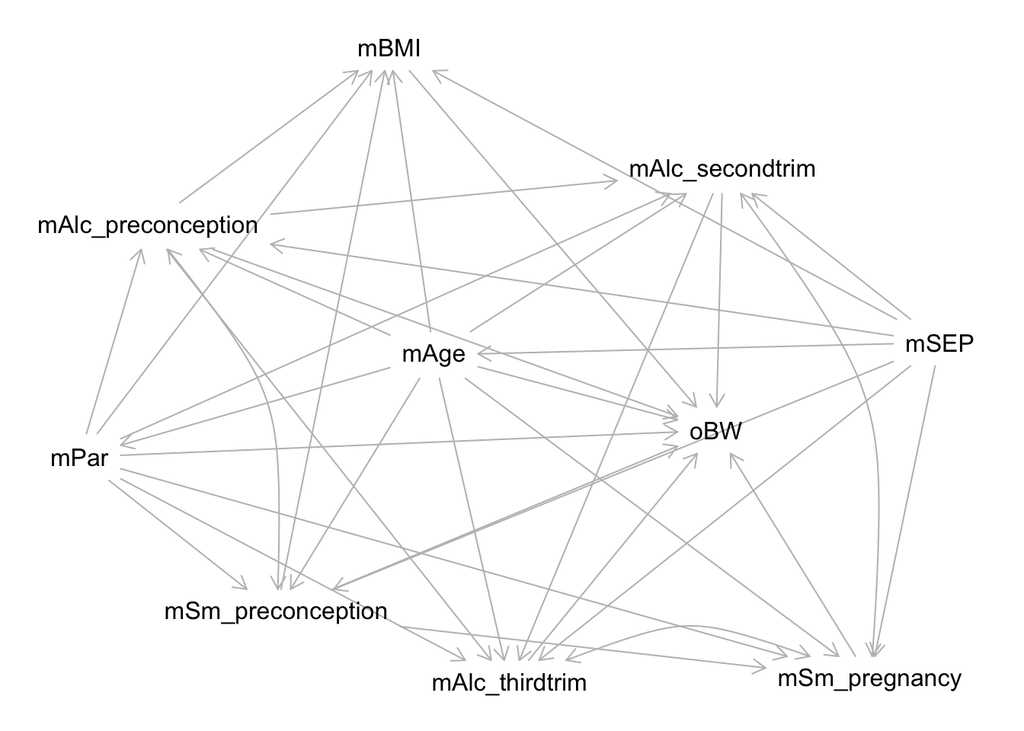

```r
g2 <- dagitty( "dag {
  mAge -> mAlc_preconception
  mAge -> mAlc_secondtrim
  mAge -> mAlc_thirdtrim
  mAge -> mBMI
  mAge -> mPar
  mAge -> mSm_preconception
  mAge -> mSm_pregnancy
  mAge -> oBW
  mSm_preconception -> mSm_pregnancy
  mBMI -> oBW
  mAlc_preconception -> mAlc_secondtrim
  mAlc_preconception -> mAlc_thirdtrim
  mAlc_preconception <-> mSm_preconception
  mAlc_preconception -> mBMI
  mAlc_preconception -> oBW
  mAlc_secondtrim -> mAlc_thirdtrim
  mAlc_secondtrim -> oBW
  mAlc_secondtrim <-> mSm_pregnancy
  mAlc_thirdtrim -> oBW
  mAlc_thirdtrim <-> mSm_pregnancy
  mPar -> mBMI
  mPar -> mAlc_preconception
  mPar -> mAlc_secondtrim
  mPar -> mAlc_thirdtrim
  mPar -> mSm_preconception
  mPar -> mSm_pregnancy
  mPar -> oBW
  mSEP -> mBMI
  mSEP -> mAge
  mSEP -> mAlc_preconception
  mSEP -> mAlc_secondtrim
  mSEP -> mAlc_thirdtrim
  mSEP -> mSm_preconception
  mSEP -> mSm_pregnancy
  mSm_preconception -> mBMI
  mSm_preconception -> oBW
  mSm_pregnancy -> oBW
}")

plot(graphLayout(g2))
```

```r
adjustmentSets(g2,"mSm_preconception","oBW") #age, parity, alcohol preconception, SEP
```

```
## { mAge, mAlc_preconception, mPar, mSEP }
```

```r
adjustmentSets(g2,"mSm_pregnancy","oBW") #age, parity, alcohol preconception, alcohol in preg, smoking preconception, SEP
```

```
## { mAge, mAlc_preconception, mAlc_secondtrim, mAlc_thirdtrim, mBMI,
##   mPar, mSm_preconception }
## { mAge, mAlc_preconception, mAlc_secondtrim, mAlc_thirdtrim, mPar,
##   mSEP, mSm_preconception }
```

```r
adjustmentSets(g2,"mAlc_preconception","oBW") #age, parity, smoking preconception, SEP
```

```
## { mAge, mPar, mSEP, mSm_preconception }
```

```r
adjustmentSets(g2,"mAlc_secondtrim","oBW") #returns nothing, but this is because it doesn't know that third trim alcohol is a time-dependent variable that doesn't "exist" at second trim
adjustmentSets(g2,"mAlc_thirdtrim","oBW") #age, parity, alcohol preconception, alcohol in previous trimesters, smoking preconception, smoking in pregnancy, SEP)
```

```
## { mAge, mAlc_preconception, mAlc_secondtrim, mBMI, mPar,
##   mSm_preconception, mSm_pregnancy }
## { mAge, mAlc_preconception, mAlc_secondtrim, mPar, mSEP,
##   mSm_preconception, mSm_pregnancy }
```

SUMMARY OF DAG2: adjust for age and SEP and maternal parity

also adjust for correlated health behaviours in the current and previous timepoints

### DAG3: considering timing of exposure (paternal exposures)

- no direct effect of paternal alcohol during pregnancy on offspring birthweight
- possible indirect effect on mothers’ alcohol consumption during pregnancy
- possible direct effect of paternal smoking on offspring birthweight (“direct” according to the DAG, but actually via exposing mother to secondhand smoke)

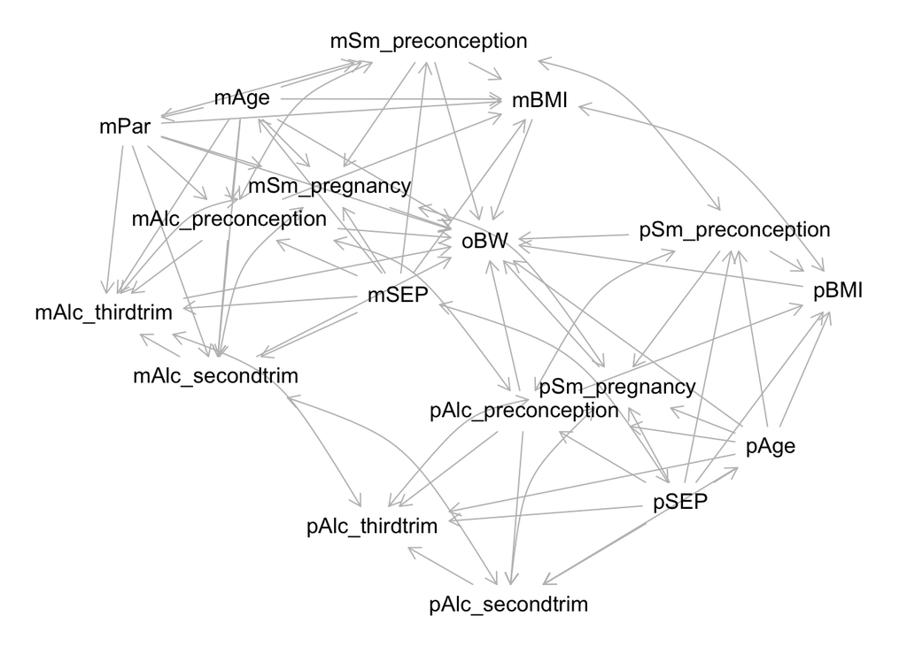

```r
g3 <- dagitty( "dag {
  pAge -> pAlc_preconception
  pAge -> pAlc_secondtrim
  pAge -> pAlc_thirdtrim
  pAge -> pBMI
  pAge -> pSm_preconception
  pAge -> pSm_pregnancy
  pAge -> oBW
  pSm_preconception -> pSm_pregnancy
  pBMI -> oBW
  pAlc_preconception -> pAlc_secondtrim
  pAlc_preconception -> pAlc_thirdtrim
  pAlc_preconception <-> pSm_preconception
  pAlc_preconception -> pBMI
  pAlc_preconception -> oBW
  pAlc_secondtrim -> pAlc_thirdtrim
  pAlc_secondtrim <-> pSm_pregnancy
  pAlc_thirdtrim <-> pSm_pregnancy
  pSEP -> pBMI
  pSEP -> pAge
  pSEP -> pAlc_preconception
  pSEP -> pAlc_secondtrim
  pSEP -> pAlc_thirdtrim
  pSEP -> pSm_preconception
  pSEP -> pSm_pregnancy
  pSm_preconception -> pBMI
  pSm_preconception -> oBW
  pSm_pregnancy -> oBW

  pSEP <-> mSEP
  pSm_pregnancy <-> mSm_pregnancy
  pSm_preconception <-> mSm_preconception
  pAlc_preconception <-> mAlc_preconception
  pAlc_secondtrim <-> mAlc_secondtrim
  pAlc_thirdtrim <-> mAlc_thirdtrim
  pBMI <-> mBMI

  mAge -> mAlc_preconception
  mAge -> mAlc_secondtrim
  mAge -> mAlc_thirdtrim
  mAge -> mBMI
  mAge -> mPar
  mAge -> mSm_preconception
  mAge -> mSm_pregnancy
  mAge -> oBW
  mSm_preconception -> mSm_pregnancy
  mBMI -> oBW
  mAlc_preconception -> mAlc_secondtrim
  mAlc_preconception -> mAlc_thirdtrim
  mAlc_preconception <-> mSm_preconception
  mAlc_preconception -> mBMI
  mAlc_preconception -> oBW
  mAlc_secondtrim -> mAlc_thirdtrim
  mAlc_secondtrim -> oBW
  mAlc_secondtrim <-> mSm_pregnancy
  mAlc_thirdtrim -> oBW
  mAlc_thirdtrim <-> mSm_pregnancy
  mPar -> mBMI
  mPar -> mAlc_preconception
  mPar -> mAlc_secondtrim
  mPar -> mAlc_thirdtrim
  mPar -> mSm_preconception
  mPar -> mSm_pregnancy
  mPar -> oBW
  mSEP -> mBMI
  mSEP -> mAge
  mSEP -> mAlc_preconception
  mSEP -> mAlc_secondtrim
  mSEP -> mAlc_thirdtrim
  mSEP -> mSm_preconception
  mSEP -> mSm_pregnancy
  mSm_preconception -> mBMI
  mSm_preconception -> oBW
  mSm_pregnancy -> oBW
}")

plot(graphLayout(g3))
```

```r
adjustmentSets(g3,"mSm_preconception","oBW") # mother: age, parity, alcohol preconception, SEP; father: age, alcohol preconception, SEP, smoking preconception
```

```
## { mAge, mAlc_preconception, mPar, mSEP, pAge, pAlc_preconception, pSEP,
##   pSm_preconception }
```

```r
adjustmentSets(g3,"mSm_pregnancy","oBW") # mother: age, parity, alcohol preconception, alcohol in preg, smoking preconception, SEP; father: age, SEP, smoking preconception, smoking in pregnancy
```

```
## { mAge, mAlc_preconception, mAlc_secondtrim, mAlc_thirdtrim, mBMI,
##   mPar, mSm_preconception, pAge, pAlc_preconception, pBMI,
##   pSm_preconception, pSm_pregnancy }
## { mAge, mAlc_preconception, mAlc_secondtrim, mAlc_thirdtrim, mPar,
##   mSEP, mSm_preconception, pAge, pSEP, pSm_preconception, pSm_pregnancy
##   }
```

```r
adjustmentSets(g3,"mAlc_preconception","oBW") # mother: age, parity, smoking preconception, SEP; father: age, alcohol preconception, SEP, smoking preconception
```

```
## { mAge, mPar, mSEP, mSm_preconception, pAge, pAlc_preconception, pSEP,
##   pSm_preconception }
```

```r
adjustmentSets(g3,"mAlc_secondtrim","oBW") #returns nothing, but this is because it doesn't know that third trim alcohol is a time-dependent variable that doesn't "exist" at second trim
adjustmentSets(g3,"mAlc_thirdtrim","oBW") # mother: age, parity, smoking preconception, smoking in pregnancy, alcohol in previous trimesters & preconception, SEP; father: age, SEP, smoking preconception, smoking in pregnancy
```

```
## { mAge, mAlc_preconception, mAlc_secondtrim, mBMI, mPar,
##   mSm_preconception, mSm_pregnancy, pAge, pAlc_preconception, pBMI,
##   pSm_preconception, pSm_pregnancy }
## { mAge, mAlc_preconception, mAlc_secondtrim, mPar, mSEP,
##   mSm_preconception, mSm_pregnancy, pAge, pSEP, pSm_preconception,
##   pSm_pregnancy }
```

```r
adjustmentSets(g3,"pSm_preconception","oBW") # mother: age, parity, alcohol preconception, SEP, smoking preconception; father: age, alcohol preconception, SEP
```

```
## { mAge, mAlc_preconception, mPar, mSEP, mSm_preconception, pAge,
##   pAlc_preconception, pSEP }
```

```r
adjustmentSets(g3,"pSm_pregnancy","oBW") # mother: age, parity, alcohol preconception, alcohol in preg, smoking preconception, SEP, smoking in pregnancy; father: age, SEP, smoking preconception
```

```
## { mAge, mAlc_preconception, mAlc_secondtrim, mAlc_thirdtrim, mBMI,
##   mPar, mSm_preconception, mSm_pregnancy, pAge, pAlc_preconception,
##   pBMI, pSm_preconception }
## { mAge, mAlc_preconception, mAlc_secondtrim, mAlc_thirdtrim, mPar,
##   mSEP, mSm_preconception, mSm_pregnancy, pAge, pSEP, pSm_preconception
##   }
```

```r
adjustmentSets(g3,"pAlc_preconception","oBW") # mother: age, parity, smoking preconception, alcohol preconception, SEP; father: age, SEP, smoking preconception
```

```
## { mAge, mAlc_preconception, mPar, mSEP, mSm_preconception, pAge, pSEP,
##   pSm_preconception }
```

```r
adjustmentSets(g3,"pAlc_secondtrim","oBW") # mother: age, parity, alcohol preconception, alcohol in pregnancy, smoking preconception, smoking in pregnancy, SEP; father: age, SEP, smoking preconception, smoking in pregnancy, alcohol preconception
```

```
## { mAge, mAlc_preconception, mAlc_secondtrim, mAlc_thirdtrim, mBMI,
##   mPar, mSm_preconception, mSm_pregnancy, pAge, pAlc_preconception,
##   pBMI, pSm_preconception, pSm_pregnancy }
## { mAge, mAlc_preconception, mAlc_secondtrim, mAlc_thirdtrim, mPar,
##   mSEP, mSm_preconception, mSm_pregnancy, pAge, pAlc_preconception,
##   pSEP, pSm_preconception, pSm_pregnancy }
```

```r
adjustmentSets(g3,"pAlc_thirdtrim","oBW") # mother: age, parity, alcohol preconception, alcohol in pregnancy, smoking preconception, smoking in pregnancy, SEP; father: age, SEP, smoking preconception, smoking in pregnancy, alcohol preconception
```

```
## { mAge, mAlc_preconception, mAlc_secondtrim, mAlc_thirdtrim, mBMI,
##   mPar, mSm_preconception, mSm_pregnancy, pAge, pAlc_preconception,
##   pBMI, pSm_preconception, pSm_pregnancy }
## { mAge, mAlc_preconception, mAlc_secondtrim, mAlc_thirdtrim, mPar,
##   mSEP, mSm_preconception, mSm_pregnancy, pAge, pAlc_preconception,
##   pSEP, pSm_preconception, pSm_pregnancy }
```

SUMMARY OF DAG3: adjust for age and SEP and maternal parity

also adjust for correlated health behaviours in the current and previous timepoints (for the exposed parent)

for the adjusted parent, adjust for the same and correlated health behaviours in the current and previous timepoints IF they can have a direct effect (or via secondhand smoke) on fetal development

only smoking is the only paternal exposure that can affect the fetus DURING PREGNANCY

### DAG 4 (adjusting for parents’ health - genetic/familial confounding)

The following DAG is the same as DAG3 but with the addition of maternal and paternal asthma, and birthweight has been swapped for child asthma

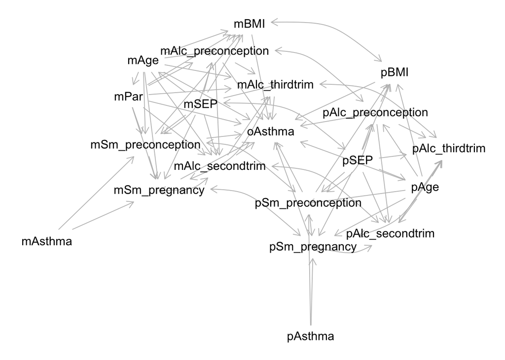

```r
g4 <- dagitty( "dag {
  pAge -> pAlc_preconception
  pAge -> pAlc_secondtrim
  pAge -> pAlc_thirdtrim
  pAge -> pBMI
  pAge -> pSm_preconception
  pAge -> pSm_pregnancy
  pAge -> oAsthma
  pSm_preconception -> pSm_pregnancy
  pBMI -> oAsthma
  pAlc_preconception -> pAlc_secondtrim
  pAlc_preconception -> pAlc_thirdtrim
  pAlc_preconception <-> pSm_preconception
  pAlc_preconception -> pBMI
  pAlc_preconception -> oAsthma
  pAlc_secondtrim -> pAlc_thirdtrim
  pAlc_secondtrim <-> pSm_pregnancy
  pAlc_thirdtrim <-> pSm_pregnancy
  pSEP -> pBMI
  pSEP -> pAge
  pSEP -> pAlc_preconception
  pSEP -> pAlc_secondtrim
  pSEP -> pAlc_thirdtrim
  pSEP -> pSm_preconception
  pSEP -> pSm_pregnancy
  pSm_preconception -> pBMI
  pSm_preconception -> oAsthma
  pSm_pregnancy -> oAsthma

  pSEP <-> mSEP
  pSm_pregnancy <-> mSm_pregnancy
  pSm_preconception <-> mSm_preconception
  pAlc_preconception <-> mAlc_preconception
  pAlc_secondtrim <-> mAlc_secondtrim
  pAlc_thirdtrim <-> mAlc_thirdtrim
  pBMI <-> mBMI

  mAge -> mAlc_preconception
  mAge -> mAlc_secondtrim
  mAge -> mAlc_thirdtrim
  mAge -> mBMI
  mAge -> mPar
  mAge -> mSm_preconception
  mAge -> mSm_pregnancy
  mAge -> oAsthma
  mSm_preconception -> mSm_pregnancy
  mBMI -> oAsthma
  mAlc_preconception -> mAlc_secondtrim
  mAlc_preconception -> mAlc_thirdtrim
  mAlc_preconception <-> mSm_preconception
  mAlc_preconception -> mBMI
  mAlc_preconception -> oAsthma
  mAlc_secondtrim -> mAlc_thirdtrim
  mAlc_secondtrim -> oAsthma
  mAlc_secondtrim <-> mSm_pregnancy
  mAlc_thirdtrim -> oAsthma
  mAlc_thirdtrim <-> mSm_pregnancy
  mPar -> mBMI
  mPar -> mAlc_preconception
  mPar -> mAlc_secondtrim
  mPar -> mAlc_thirdtrim
  mPar -> mSm_preconception
  mPar -> mSm_pregnancy
  mPar -> oAsthma
  mSEP -> mBMI
  mSEP -> mAge
  mSEP -> mAlc_preconception
  mSEP -> mAlc_secondtrim
  mSEP -> mAlc_thirdtrim
  mSEP -> mSm_preconception
  mSEP -> mSm_pregnancy
  mSm_preconception -> mBMI
  mSm_preconception -> oAsthma
  mSm_pregnancy -> oAsthma
  mAsthma -> mSm_pregnancy
  pAsthma -> pSm_pregnancy
  mAsthma -> mSm_preconception
  pAsthma -> pSm_preconception
}")

plot(graphLayout(g4))
```

```r
adjustmentSets(g4,"mSm_preconception","oAsthma") # all as DAG3 plus maternal and paternal asthma
```

```
## { mAge, mAlc_preconception, mAsthma, mPar, mSEP, pAge,
##   pAlc_preconception, pAsthma, pSEP, pSm_preconception }
```

```r
adjustmentSets(g4,"mAlc_preconception","oAsthma") # all as DAG3 plus maternal and paternal asthma
```

```
## { mAge, mAsthma, mPar, mSEP, mSm_preconception, pAge,
##   pAlc_preconception, pAsthma, pSEP, pSm_preconception }
```

```r
adjustmentSets(g4,"pSm_preconception","oAsthma") # all as DAG3 plus maternal and paternal asthma
```

```
## { mAge, mAlc_preconception, mAsthma, mPar, mSEP, mSm_preconception,
##   pAge, pAlc_preconception, pAsthma, pSEP }
```

```r
adjustmentSets(g4,"pAlc_preconception","oAsthma") # all as DAG3 plus maternal and paternal asthma
```

```
## { mAge, mAlc_preconception, mAlc_secondtrim, mAlc_thirdtrim, mPar,
##   mSEP, mSm_preconception, mSm_pregnancy, pAge, pSEP,
##   pSm_preconception, pSm_pregnancy }
## { mAge, mAlc_preconception, mAsthma, mPar, mSEP, mSm_preconception,
##   pAge, pAsthma, pSEP, pSm_preconception }
```

```r
adjustmentSets(g4,"pAlc_secondtrim","oAsthma") # as DAG3 BUT NO MATERNAL OR PATERNAL ASTHMA...
```

```
## { mAge, mAlc_preconception, mAlc_secondtrim, mAlc_thirdtrim, mBMI,
##   mPar, mSm_preconception, mSm_pregnancy, pAge, pAlc_preconception,
##   pBMI, pSm_preconception, pSm_pregnancy }
## { mAge, mAlc_preconception, mAlc_secondtrim, mAlc_thirdtrim, mPar,
##   mSEP, mSm_preconception, mSm_pregnancy, pAge, pAlc_preconception,
##   pSEP, pSm_preconception, pSm_pregnancy }
```

```r
adjustmentSets(g4,"pAlc_thirdtrim","oAsthma") # as DAG3 BUT NO MATERNAL OR PATERNAL ASTHMA..
```

```
## { mAge, mAlc_preconception, mAlc_secondtrim, mAlc_thirdtrim, mBMI,
##   mPar, mSm_preconception, mSm_pregnancy, pAge, pAlc_preconception,
##   pBMI, pSm_preconception, pSm_pregnancy }
## { mAge, mAlc_preconception, mAlc_secondtrim, mAlc_thirdtrim, mPar,
##   mSEP, mSm_preconception, mSm_pregnancy, pAge, pAlc_preconception,
##   pSEP, pSm_preconception, pSm_pregnancy }
```